# Salary Veri Seti ANOVA Analizi

Duygu Eryılmaz

2026-05-26

# 1. Veri Setini İçe Aktarma

```r
salary_veri <- read.csv("Salary.csv")

head(salary_veri)
```

```
##   Salary Gender Age PhD
## 1  140.0      1  47   1
## 2   30.0      0  65   1
## 3   35.1      0  56   0
## 4   30.0      1  23   0
## 5   80.0      0  53   1
## 6   30.0      0  27   0
```

```r
str(salary_veri)
```

```
## 'data.frame':    100 obs. of  4 variables:
##  $ Salary: num  140 30 35.1 30 80 30 60 31.1 125 51 ...
##  $ Gender: int  1 0 0 1 0 0 1 0 1 1 ...
##  $ Age   : int  47 65 56 23 53 27 53 30 44 63 ...
##  $ PhD   : int  1 1 0 0 1 0 0 0 1 1 ...
```

Veri seti başarıyla sisteme aktarılmıştır. Veri setinde Salary, Gender, Age ve PhD değişkenleri bulunmaktadır. Gender ve PhD değişkenleri kategorik yapıdadır.

# 2. Faktör Dönüşümleri

```r
salary_veri$Gender <- factor(
  salary_veri$Gender,
  levels = c(0,1),
  labels = c("Kadin", "Erkek")
)

salary_veri$PhD <- factor(
  salary_veri$PhD,
  levels = c(0,1),
  labels = c("PhD_Yok", "PhD_Var")
)

str(salary_veri)
```

```
## 'data.frame':    100 obs. of  4 variables:
##  $ Salary: num  140 30 35.1 30 80 30 60 31.1 125 51 ...
##  $ Gender: Factor w/ 2 levels "Kadin","Erkek": 2 1 1 2 1 1 2 1 2 2 ...
##  $ Age   : int  47 65 56 23 53 27 53 30 44 63 ...
##  $ PhD   : Factor w/ 2 levels "PhD_Yok","PhD_Var": 2 2 1 1 2 1 1 1 2 2 ...
```

Gender ve PhD değişkenleri factor tipine dönüştürülmüştür. Böylece ANOVA analizinin doğru şekilde çalışması sağlanmıştır.

# 3. Boxplot

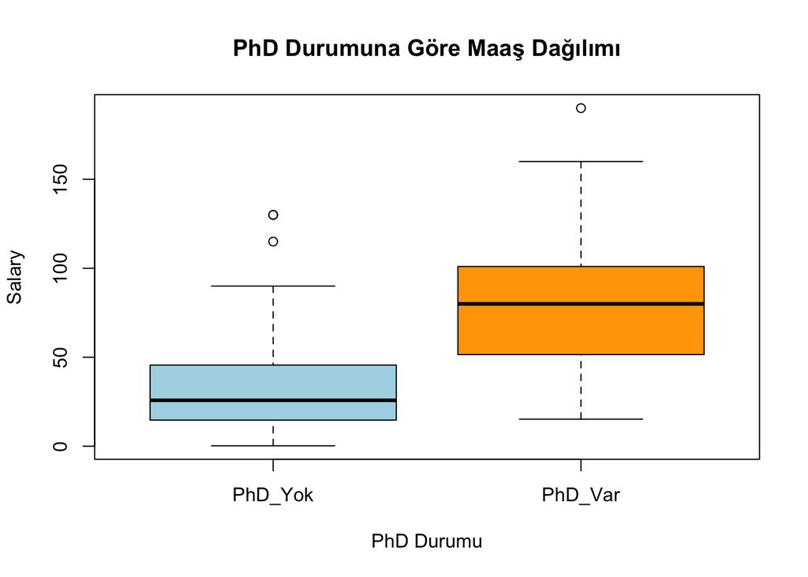

```r
boxplot(
  Salary ~ PhD,
  data = salary_veri,
  main = "PhD Durumuna Göre Maaş Dağılımı",
  xlab = "PhD Durumu",
  ylab = "Salary",
  col = c("lightblue", "orange")
)
```

Boxplot grafiği grupların maaş dağılımlarını göstermektedir. Medyan değerler ve dağılımlar incelenerek gruplar arasındaki fark gözlemlenebilir. Aykırı değerler grafik üzerinden görülebilmektedir.

# 4. Normallik Testi

```r
by(
  salary_veri$Salary,
  salary_veri$PhD,
  shapiro.test
)
```

```
## salary_veri$PhD: PhD_Yok
##
##  Shapiro-Wilk normality test
##
## data:  dd[x, ]
## W = 0.84795, p-value = 2.266e-06
##
## ------------------------------------------------------------
## salary_veri$PhD: PhD_Var
##
##  Shapiro-Wilk normality test
##
## data:  dd[x, ]
## W = 0.95129, p-value = 0.0908
```

H0: Veriler normal dağılım göstermektedir. p-value > 0.05 ise normallik varsayımı sağlanır. p-value < 0.05 ise normallik varsayımı sağlanmaz.

# 5. Levene Testi

```r
library(car)
leveneTest(
  Salary ~ PhD,
  data = salary_veri
)
```

```
## Levene's Test for Homogeneity of Variance (center = median)
##       Df F value  Pr(>F)
## group  1  6.4075 0.01295 *
##       98
## ---
## Signif. codes:  0 '***' 0.001 '**' 0.01 '*' 0.05 '.' 0.1 ' ' 1
```

H0: Grup varyansları homojendir. p-value > 0.05 ise varyans homojenliği sağlanmaktadır. Bu durumda ANOVA testi uygulanabilir.

# 6. İki Faktörlü ANOVA

```r
iki_yonlu <- aov(
  Salary ~ Gender + PhD,
  data = salary_veri
)

summary(iki_yonlu)
```

```
##             Df Sum Sq Mean Sq F value   Pr(>F)
## Gender       1  11867   11867   9.795  0.00231 **
## PhD          1  47094   47094  38.872 1.18e-08 ***
## Residuals   97 117517    1212
## ---
## Signif. codes:  0 '***' 0.001 '**' 0.01 '*' 0.05 '.' 0.1 ' ' 1
```

Bu analiz iki bağımsız değişkenin maaş üzerindeki etkisini birlikte incelemektedir. Her değişkenin ayrı ayrı anlamlılığı değerlendirilmektedir.

# 7. Etkileşimli ANOVA

```r
etkilesim_modeli <- aov(
  Salary ~ Gender * PhD,
  data = salary_veri
)

summary(etkilesim_modeli)
```

```
##             Df Sum Sq Mean Sq F value   Pr(>F)
## Gender       1  11867   11867   9.865  0.00224 **
## PhD          1  47094   47094  39.151 1.09e-08 ***
## Gender:PhD   1   2038    2038   1.694  0.19617
## Residuals   96 115479    1203
## ---
## Signif. codes:  0 '***' 0.001 '**' 0.01 '*' 0.05 '.' 0.1 ' ' 1
```

Gender:PhD satırı etkileşim etkisini göstermektedir. p-value < 0.05 ise ortak etkileşim anlamlıdır. p-value > 0.05 ise ortak etkileşim anlamlı değildir.

# 8. Kruskal-Wallis Testi

```r
kruskal.test(
  Salary ~ PhD,
  data = salary_veri
)
```

```
##
##  Kruskal-Wallis rank sum test
##
## data:  Salary by PhD
## Kruskal-Wallis chi-squared = 33.307, df = 1, p-value = 7.869e-09
```

Normallik varsayımı sağlanmazsa bu test tercih edilmektedir. p-value < 0.05 ise gruplar arasında anlamlı fark vardır. p-value > 0.05 ise anlamlı fark bulunmamaktadır.